# lab members

2022-05-20

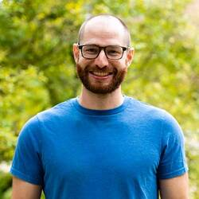

[Dr. Justin Silverman, MD, PhD](http://justin-silverman.com)  
Principle Investigator

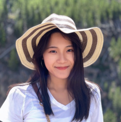

[Tinghua Chen](https://ist.psu.edu/directory/tuc579)  
PhD Student, Informatics  
*Scalable Bayesian Semiparametrics, Causal Inference*

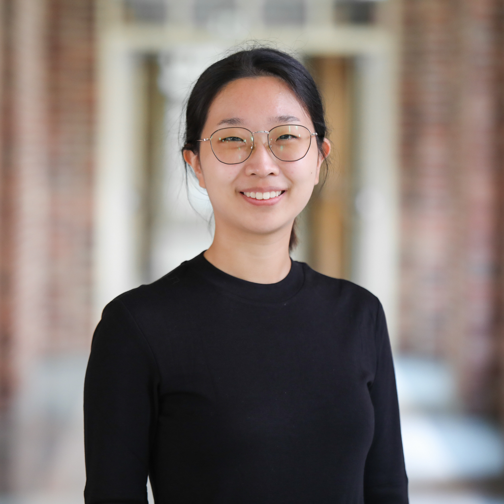

[Won Gu](https://science.psu.edu/stat/people/wpg5129)  
PhD Student, Statistics  
*Sparse Bayesian Partially Identified Models, Theory of Identifiability, Measure Theory*

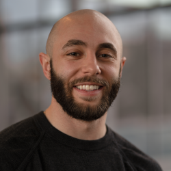

[Maxwell Konnaris](https://maxwellkonnaris.com/)  
PhD Student, Bioinformatics and Genomics  
*Scale Reliant Covariance Estimation, Machine Learning Methods for Quantitative Sequence Analysis*

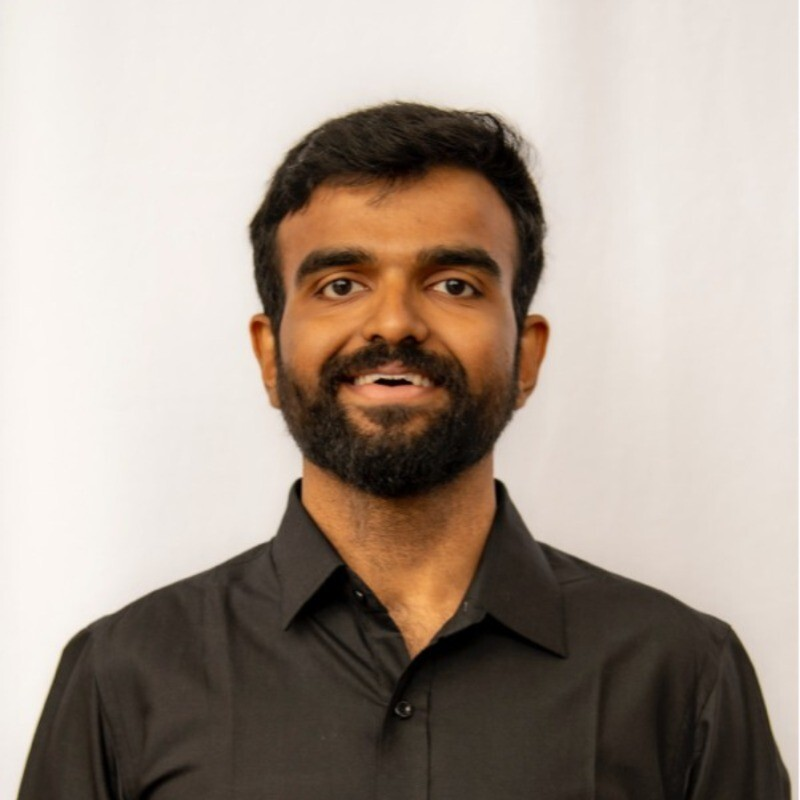

[Dharmik Rathod](https://www.linkedin.com/in/dharmikrathod/)  
Masters Student, Informatics  
*Bayesian Hierarchical Linear Models, PCR Bias*

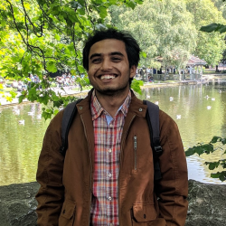

[Manan Saxena](https://www.linkedin.com/in/manansaxena05/)  
Masters (Graduated)  
and PhD Student (Current), Informatics  
*Scalable Bayesian Hierarchical Time-Series Models, Theory of Invariance in ML/AI, Functional Data Analysis*

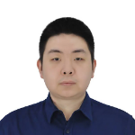

[Ziang Shi](https://ist.psu.edu/directory/zjs5273)  
PhD Student, Informatics  
*Uncertainty Quantification in Black-Box ML/AI Models*

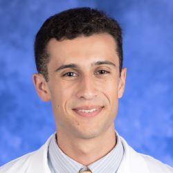

[Andrew Sugarman](https://pubmed.ncbi.nlm.nih.gov/?term=Andrew+Sugarman)  
MD and PhD Student, Bioinformatics and Genomics  
*Applications of Topological and Functional Data Analysis to Image Analysis in Oncology*

# Graduated

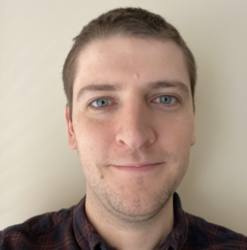

[Dr. Kyle McGovern, PhD](https://www.huck.psu.edu/people/kyle-mcgovern)  
PhD in Bioinformatics and Genomics  
*Scale Reliant Inference, Bayesian-Frequentist Hybrid Methods, Microbiome and Gene Expression Studies*

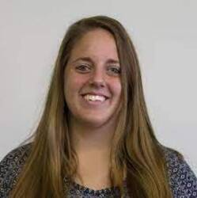

[Dr. Michelle Nixon, PhD](https://ist.psu.edu/directory/map5672)  
Assistant Research Professor  
*Scale Reliant Inference, Genomics, Clinical Informatics*

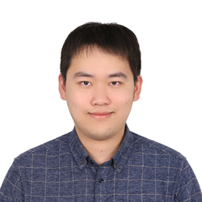

[Zhao Ma](https://www.zhaoma98.com/)  
Masters of Science in Informatics  
*Scale Reliant Inference, High-Dimensional Covariance Estimation*

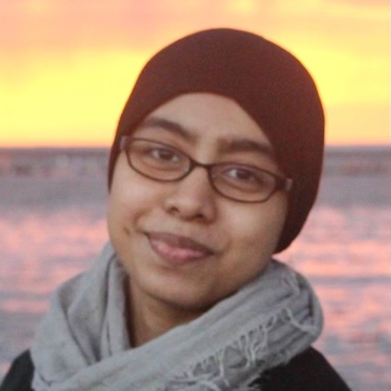

[Farhani Momotaz](https://www.linkedin.com/in/farhani-momo/)  
Masters of Science in Informatics  
*Bayesian Decision Theory in Clinical Medicine*